# Augmenting View Count data into Superbowl Ads

Alex Moyse

# Project Background

Practically, I wanted to set up the basics of a set for a predictor that links the year, the content, and the 3rd party views on youtube. I wanted to practice selenium scraping in R, and this seemed a perfect example as this already has links This project made me realize how much more limited RSelenium is than the supported languages are.

This Stack Requires:

1. Docker
2. Jupyter
3. Selenium Container
4. RSelenium

# Article Overview

In terms of Article, FiveThirtyEight analyzed and categorized Superbowl commercials. Superbowl ads are remarkably expensive to run, and a lot of thought goes into targeting specific audiences for a commercial. I wanted to look more into the data and determine if one could predict the view count on Youtube after the fact to see if there was any long term impact.Practically, I wanted to set up the basics of a set for a predictor that links the year, the content, and the 3rd party views on YouTube.

I wanted to practice selenium scraping in R, and this seemed a perfect example as this already has links. Through scraping, I realized that these were not all OEM hosted, as well as the view count seemed artificially low or high, so I decided to not attempt to make a predictor due to the low data count and sheer variance in the source of the view count.

# Sample Data

This is just the head of the raw data from FiveThirtyEight.

```r
url.data <- "https://raw.githubusercontent.com/fivethirtyeight/superbowl-ads/main/superbowl-ads.csv"
raw <- read.csv(url(url.data), header = TRUE,)
knitr::kable(head(raw), "simple")
```

| year | brand | superbowl_ads_dot_com_url | youtube_url | funny | show_product_quickly | patriotic | celebrity | danger | animals | use_sex |
| --- | --- | --- | --- | --- | --- | --- | --- | --- | --- | --- |
| 2018 | Toyota | https://superbowl-ads.com/good-odds-toyota/ | https://www.youtube.com/watch?v=zeBZvwYQ-hA | False | False | False | False | False | False | False |
| 2020 | Bud Light | https://superbowl-ads.com/2020-bud-light-seltzer-inside-posts-brain/ | https://www.youtube.com/watch?v=nbbp0VW7z8w | True | True | False | True | True | False | False |
| 2006 | Bud Light | https://superbowl-ads.com/2006-bud-light-bear-attack/ | https://www.youtube.com/watch?v=yk0MQD5YgV8 | True | False | False | False | True | True | False |
| 2018 | Hynudai | https://superbowl-ads.com/hope-detector-nfl-super-bowl-lii-hyundai/ | https://www.youtube.com/watch?v=lNPccrGk77A | False | True | False | False | False | False | False |
| 2003 | Bud Light | https://superbowl-ads.com/2003-bud-light-hermit-crab/ | https://www.youtube.com/watch?v=ovQYgnXHooY | True | True | False | False | True | True | True |
| 2020 | Toyota | https://superbowl-ads.com/2020-toyota-go-places-with-cobie-smulders/ | https://www.youtube.com/watch?v=f34Ji70u3nk | True | True | False | True | True | True | False |

Here is where we would augment the data with the Selenium Instance

```r
for (row_number in 1:length){
        remDr$navigate(as.character(raw$youtube[row_number]))
        Sys.sleep(5.0) #Could not find a way to wait for complete page load, so I threw in a wait to ensure load
        webElem <- tryCatch({remDr$findElement(using = "css", "[class='view-count style-scope ytd-video-view-count-renderer']")},
                            error = function(e){ print("Could Not Find Video")})
        view_number_text <- ""
        if(!is.null(webElem)){
            view_number_text <- tryCatch({webElem$getElementText()},
                                error = function(e){ print("Could Not get View Count Value")})
        } else {
            print("I could not find target")
        }
        view_number_text = gsub("views", "", view_number_text)
        view_number_text = gsub(",", "", view_number_text)
        if (Dev_Checks){
            print(raw[row_number,]['youtube_url'])
            print(view_number_text)
        }
        raw$Views[row_number] <- view_number_text
    }
```

Here is where we proceed to remove the Superbowl ads dot com url as well as the YouTube url because they are not needed for the predictor.

```r
url.data <- "https://raw.githubusercontent.com/Amantux/Data607_Assignment1/main/Superbowl_adds_count.csv"
raw <- read.csv(url(url.data), header = TRUE,)
c_dat = subset(raw, select = -c(superbowl_ads_dot_com_url,youtube_url))
knitr::kable(head(c_dat), "simple")
```

| year | brand | funny | show_product_quickly | patriotic | celebrity | danger | animals | use_sex | Views |
| --- | --- | --- | --- | --- | --- | --- | --- | --- | --- |
| 2018 | Toyota | False | False | False | False | False | False | False | 185328 |
| 2020 | Bud Light | True | True | False | True | True | False | False | 78717 |
| 2006 | Bud Light | True | False | False | False | True | True | False | 142558 |
| 2018 | Hynudai | False | True | False | False | False | False | False | 240 |
| 2003 | Bud Light | True | True | False | False | True | True | True | 13860 |
| 2020 | Toyota | True | True | False | True | True | True | False | 28043 |

### Let’s Graph the View Count vs Year to see if there are any interesting trends

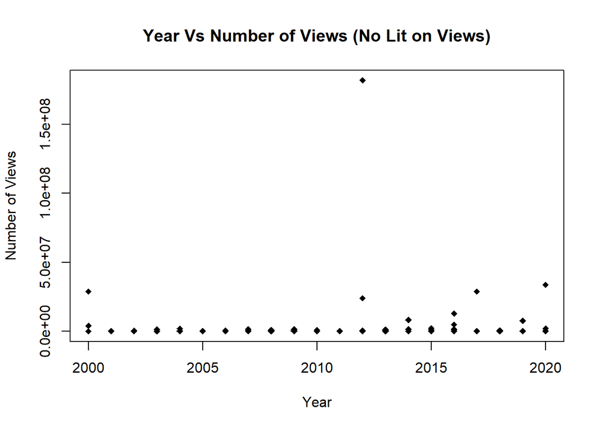

### See how the clusters change when you start limiting the number of views

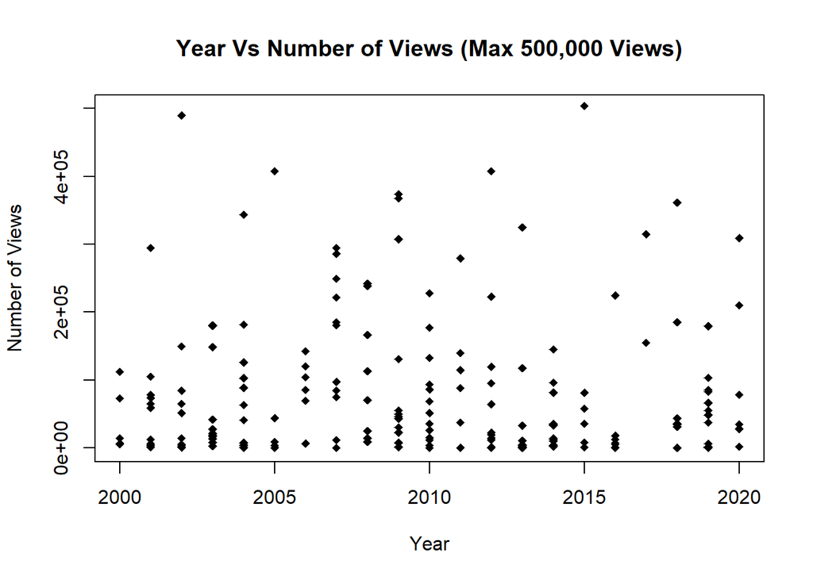

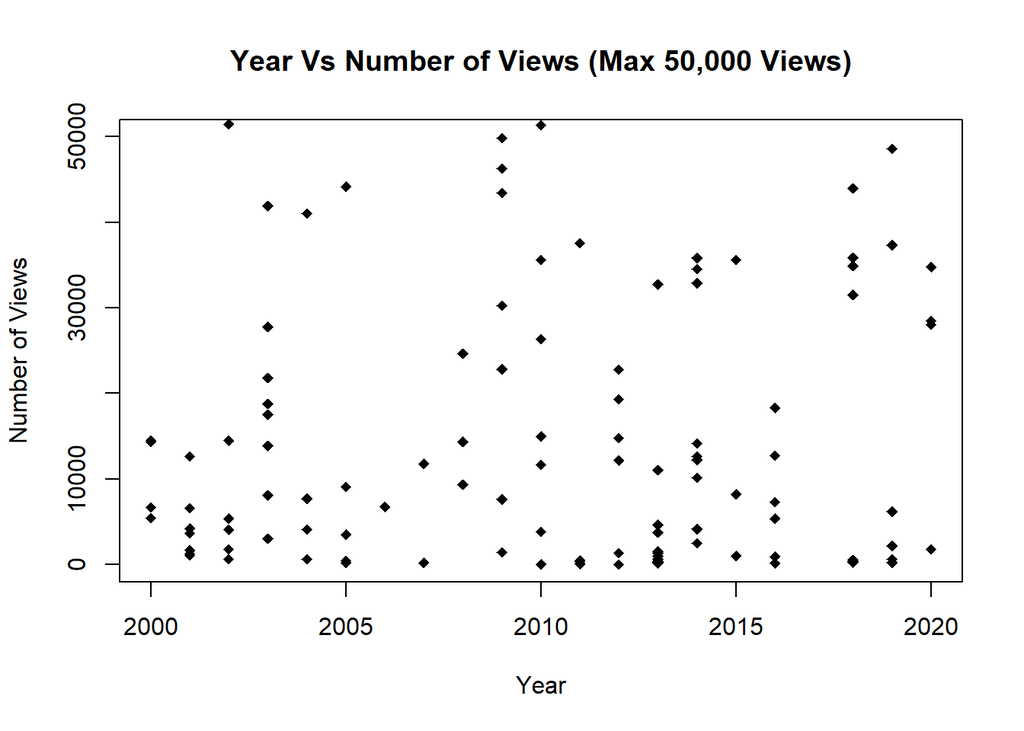

### As you can see there is a high amount of range in the data, with a large portion of advertisements having under 50,000 views. I believe this can be attributed to the variability in the source of the view count.

## Findings and Recommendations

Practically I wanted to develop the data backing a predictor, and I think I could probably do a better job of augmenting This mainly relies on scraping YouTube data, where not all cases actually even have a presence. It may be better to look at the viewership numbers from the Superbowl itself. In terms of the origin data set, I would love to see a breakdown on time or % of ad as I think that would be interesting!  
In addition, this data set pull straight from FiveThirtyEight’s Data set, so as time passes, if Fresh_Data and Fresh_Computes are both set to TRUE, with a proper container set up, they will update this whole project with new data.

## Reference

RSelenium-https://cran.r-project.org/web/packages/RSelenium/index.html Source Data Article-https://projects.fivethirtyeight.com/super-bowl-ads/ Source Data Set-https://raw.githubusercontent.com/fivethirtyeight/superbowl-ads/main/superbowl-ads.csv rmarkdown-https://rmarkdown.rstudio.com